# photon-statistics

```python
from IPython.core.display import display, HTML
display(HTML("<style>.container { width:60% !important; }</style>"))
```

### Poisson and Exponential Distributions

Two key probability distributions in photonics are the **Poisson distribution** and the **exponential distribution**. Both of these distrubutions fall under the umbrella of Poisson processes and are just two different ways of the describing the same Poisson process. The Poisson distribution is discrete and provides the probability of observing N events in a fixed time interval. On the other hand, the exponential distribution is continuous and provides the probability of a given time interval between events in a Poisson process. In photonics, the Poisson distribution gives us the probability of observing N photons during the exposure time. The exponential distribution tells us the probability a photon will be emitted as a function of time. Let's look at the Poisson distribution first:

\begin{equation*} P(n,\mu_{p}) = \frac{\mu_{p}^{n}e^{-\mu_{p}}}{n!} \end{equation*}

where $ n $ is the number of photons observed and $ \mu_{p} $ is the expected number of photons to be observed. One important feature of the Poisson distribution is that $ \mu_{p}$ can be written as the product $ \mu_{p} = \lambda t_{exp} $ where $ \lambda $ is the probability of observing a photon per unit time and $t_{exp} $ is how long you take your measurement. One important feature of the Poisson distribution is that the variance is equal to the mean or $ \mu_{p} = \sigma_{p}^{2} $ where $ \sigma_{p} = \delta n $ , which is characteristic of all Poisson processes. So, we should expect to see higher variability in the number of detected photons for higher intensities and for longer exposure times. Let's take a look at the form of the Poisson distribution for different values of $ \lambda $ keeping $t_{exp} $ fixed at 1.

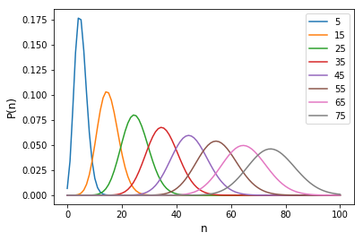

```python
import matplotlib.pyplot as plt
import numpy as np
import math
from scipy.special import factorial

def poisson(n, mu_p):
    fact = factorial(n)
    p = (mu_p**n)*math.exp(-mu_p)/fact
    return p

n = np.linspace(0,100,100)
for i in range(5, 85, 10):
    p = poisson(n, i)
    plt.plot(n,p, label=str(i))

plt.xlabel('n', fontsize=12)
plt.ylabel('P(n)', fontsize=12)
plt.legend()
plt.show()
```

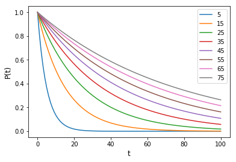

```python
import matplotlib.pyplot as plt
import numpy as np
import math
from scipy.special import factorial

def exponential(t, tau):
    p = np.exp(-t/tau)
    return p

t = np.linspace(0,100,100)
for i in range(5, 85, 10):
    p = exponential(t, i)
    plt.plot(t,p, label=str(i))

plt.xlabel('t', fontsize=12)
plt.ylabel('P(t)', fontsize=12)
plt.legend()
plt.show()
```